# 11 Least Squares

[figure not shown]

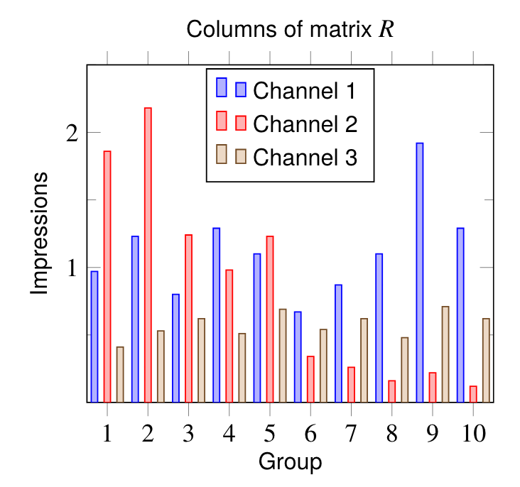

#### Unit 1: Vectors, Book ILA Ch. 1-5

#### Unit 2: Matrices, Book ILA Ch. 6-11 + Book IMC Ch. 2

#### Unit 3: Least Squares, Book ILA Ch. 12-14

- **11 Least Squares**
- 12 Least Squares Data Fitting
- 13 Least Squares Classification

# Outline: 11 Least Squares

- Least Square Problem
- Solution of Least Square Problem
- Examples

# Survey Results

Videos summarizing some of the concepts of this class:

- https://www.3blue1brown.com/topics/linear-algebra

Running the code from the lectures by clicking on Binder:

- https://github.com/bioshape-lab/ece3

Final preparation:

- Exercises from HW and class
- Review session with exercises
- Mock exam

# Least Squares Problem

$\color{#EF5645}{\text{Definition}}$: Let be given a $m \times n$ matrix $A$ and $m$-vector $b$. The least squares problem is the problem of choosing an $n$-vector $x$ to minimize: $$‖Ax − b‖^2.$$

- $‖Ax − b‖^2$ is called the objective function,
- If $\hat x$ is a solution of the linear equation $Ax = b$, then $\hat x$ is a solution of the least square problem. The converse is not true.
- $\hat x$ is a solution of least squares problem if $‖A \hat x − b‖^2 ≤ ‖Ax − b‖^2$ for any other $n$-vector $x$.

$\color{#047C91}{\text{Exercise}}$: Consider the matrix $A$ and vector $b$ as: $$A = \begin{bmatrix} 2 & 0 \\ -1 & 1 \\ 0 & 2 \end{bmatrix}, \quad b = \begin{bmatrix} 1 \\ 0 \\ -1 \end{bmatrix}.$$

Write the objective function associated to the least square problem defined by $A$ and $b$ in terms of entries of $x$.

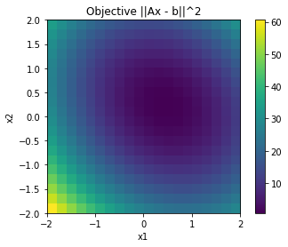

```python
# don't worry about this code
import numpy as np; import matplotlib.pyplot as plt
objective = lambda x : (2 * x[0] - 1) ** 2 + (- x[0] + x[1]) ** 2 + (2 * x[1] + 1) ** 2
n_points, xmin, xmax, ymin, ymax = 20, -2, 2, -2, 2
x = np.arange(xmin, xmax, (xmax-xmin)/(n_points)); y = np.arange(ymin, ymax, (ymax-ymin)/(n_points)); xx = np.dstack(np.meshgrid(x, y)); Z = np.zeros((n_points, n_points))
for i in range(n_points):
    for j in range(n_points):
        Z[i, j] = objective(xx[i, j])
plt.imshow(Z, extent=[xmin, xmax, ymin, ymax]); plt.colorbar(); plt.xlabel("x1"); plt.ylabel("x2"); plt.title("Objective ||Ax - b||^2");
```

# Outline: 11 Least Squares

- Least Square Problem
- **Solution of Least Square Problem**
- Examples

# Least Square Solution

$\color{#EF5645}{\text{Proposition}}$:

- Consider a least square problem $||Ax - b||^2$ for matrix $A$ and vector $b$.
- Assume that $A$ has linearly independent columns.

Then, there is a unique solution $\hat x$ to the least square problem, defined as: $$\hat x = (A^T A)^{-1} A^Tb = A^\dagger b.$$

- $A^\dagger = (A^T A)^{-1} A^T$ is called the pseudo-inverse of $A$.

$\color{#047C91}{\text{Exercise}}$ (hard): Using the fact that: $$||a + b ||^2 = ||a||^2 + ||b||^2 + 2 a^Tb,$$ prove that $\hat x$ defined in the previous slide is indeed a solution.

- Hint: Show that for any other $n$-vector $x$, we have: $$‖A x − b‖^2 \geq ‖A \hat x − b‖^2.$$
- Hint 2: You will need to show that $A^T(A\hat{x} - b) = 0$.

$\color{#003660}{\text{In Python}}$, we use:

- the function `np.linalg.lstsq`: returns the solution as the first element of the returned tuple
- the formula of the solution using transpose `.T`, inverse and matrix multiplication.

```python
A = np.array([[2, 0], [-1, 1], [0, 2]]); b = np.array([1, 0, -1]); sol1 = np.linalg.inv(A.T @ A) @ A.T @ b; print(sol1)
sol2 = np.linalg.lstsq(A, b); print(sol2)
```

```
[ 0.33333333 -0.33333333]
(array([ 0.33333333, -0.33333333]), array([0.66666667]), 2, array([2.44948974, 2.        ]))
```

# Outline: 11 Least Squares

- Least Square Problem
- Solution of Least Square Problem
- **Example**

# Political Advertising

[figure not shown]

# Example: Political Advertising

- A company wants to advertize to potential voters.
  - $m$ demographics groups, $n$ advertising channels
  - $v^{target}$ is $m$-vector of target views ("impressions") per group
  - $s$ is $n$-vector of spending per channel
  - $R$ is $m \times n$ matrix of demographic reach of channels:
    - $R_{ij}$ is number of views per dollar spent (in 1000/\$)
- How much should be spent to be as close as possible to $v^{target}$?

- $m = 10$ groups and $n=3$ channels,
- $v^{target} = 1000 . 1_m$.

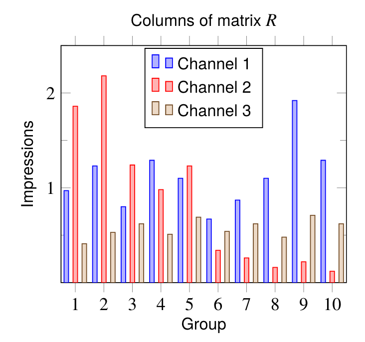

```python
import numpy as np

R = np.array([
    [0.97, 1.86, 0.41],
    [1.23, 2.18, 0.53],
    [0.8, 1.24, 0.62],
    [1.29, 0.98, 0.51],
    [1.1, 1.23, 0.69],
    [0.67, 0.34, 0.54],
    [0.87, 0.26, 0.62],
    [1.1, 0.16, 0.48],
    [1.92, 0.22, 0.71],
    [1.29, 0.12, 0.62]
])
```

# Outline: 11 Least Squares

- Least Square Problem
- Solution of Least Square Problem
- Examples